# Worksheet 12

Published

April 3, 2025

April 4, 2025

April 4, 2025

## Packages

```r
library(tidyverse)
```

## Intoxicant use according to gender and race

In a survey, 2,276 high-school students were classified according to whether or not they have ever used alcohol, cigarettes, or marijuana (responses). In the survey, each student’s race and gender (as they reported them) was also recorded (explanatory). The data are in http://ritsokiguess.site/datafiles/intoxicant.csv. The columns are labelled by the initial letter of each of these, with a column `count` that says how many students fell into that combination of categories.

1. Read in and display some of the data. How do you know you have the correct total number of students?

The usual, to kick off with:

```r
my_url <- "http://ritsokiguess.site/datafiles/intoxicant.csv"
use <- read_csv(my_url)
use
```

| a | c | m | r | g | count |
| --- | --- | --- | --- | --- | --- |
| yes | yes | yes | white | female | 405 |
| yes | yes | yes | other | female | 23 |
| yes | no | yes | white | female | 13 |
| yes | no | yes | other | female | 2 |
| no | yes | yes | white | female | 1 |
| no | yes | yes | other | female | 0 |
| no | no | yes | white | female | 1 |
| no | no | yes | other | female | 0 |
| yes | yes | no | white | female | 268 |
| yes | yes | no | other | female | 23 |

[output cut: 22 more lines]

The first five columns are respectively whether the students have ever used alcohol, cigarettes, or marijuana, then their race (classified as “white” or “other”), then their reported gender (classified as “male” or “female” only).

There are $32 = 2^5$ rows, one for each of the two levels of each of the five categorical variables. But each row contains a lot of students, namely, the number in `count`, so to find out how many students here are altogether, sum up the values in `count`:

```r
use %>% summarize(total = sum(count))
```

| total |
| --- |
| 2276 |

which checks with the question.

Extra: the tidyverse has a function amusingly called `uncount` that does the opposite of what `count` does:

```r
use %>% uncount(count)
```

| a | c | m | r | g |
| --- | --- | --- | --- | --- |
| yes | yes | yes | white | female |
| yes | yes | yes | white | female |
| yes | yes | yes | white | female |
| yes | yes | yes | white | female |
| yes | yes | yes | white | female |
| yes | yes | yes | white | female |
| yes | yes | yes | white | female |
| yes | yes | yes | white | female |
| yes | yes | yes | white | female |
| yes | yes | yes | white | female |

[output cut: 2266 more lines]

This produces one row for each individual student (you will have to scroll down a long way to get past the 405 rows of white female students who have used all three intoxicants), and hence 2,276 rows altogether.

2. Fit a log-linear model with up to two-way associations to these data. To do this, use `(a+c+m+r+g)^2` on the right side of your model formula (instead of the `a*c*r*m*g` that you were probably expecting). Run a suitable `drop1` on this model.

```r
use.1 <- glm(count ~ (a+c+m+r+g)^2, data = use, family = "poisson")
drop1(use.1, test = "Chisq")
```

|  | Df | Deviance | AIC | LRT | Pr(>Chi) |
| --- | --- | --- | --- | --- | --- |
|  | NA | 15.34034 | 183.5786 | NA | NA |
| a:c | 1 | 201.19931 | 367.4376 | 185.8589683 | 2.548473e-42 |
| a:m | 1 | 106.95800 | 273.1963 | 91.6176535 | 1.051508e-21 |
| a:r | 1 | 20.32086 | 186.5591 | 4.9805182 | 2.563430e-02 |
| a:g | 1 | 18.71695 | 184.9552 | 3.3766077 | 6.612803e-02 |
| c:m | 1 | 513.47218 | 679.7105 | 498.1318362 | 2.423520e-110 |
| c:r | 1 | 15.78347 | 182.0217 | 0.4431241 | 5.056184e-01 |
| c:g | 1 | 16.31718 | 182.5555 | 0.9768414 | 3.229799e-01 |
| m:r | 1 | 18.92894 | 185.1672 | 3.5885923 | 5.817750e-02 |
| m:g | 1 | 25.16101 | 191.3993 | 9.8206653 | 1.725619e-03 |

[output cut: 1 more lines]

You see that in the `drop1` output are all the two-way interactions (“associations” for this kind of model). This is what `^` does in a model formula, and is why we had to use `I(x^2)` to add an $x$-squared term in a regression, meaning “literally $x$-squared, not any kind of an interaction”.

The reason for doing it this way here is that if you start with `a*c*r*m*g`, you will have to eliminate the five-way interaction, then all the four-way interactions, then all the three-way interactions, before you even get down to business, where “remove” means “remove and re-fit, one by one”. I didn’t want to put you through that.

3. Build a better model. Why did you stop where you did?

Just as in regression, remove the least significant term, re-fit, then repeat until everything is significant and there is nothing left to drop.

First, remove `c:r` (P-value 0.51), then see what to do next:

```r
use.2 <- update(use.1, . ~ . - c:r)
drop1(use.2, test = "Chisq")
```

|  | Df | Deviance | AIC | LRT | Pr(>Chi) |
| --- | --- | --- | --- | --- | --- |
|  | NA | 15.78347 | 182.0217 | NA | NA |
| a:c | 1 | 201.21688 | 365.4552 | 185.4334108 | 3.156322e-42 |
| a:m | 1 | 107.79480 | 272.0331 | 92.0113313 | 8.618159e-22 |
| a:r | 1 | 20.33869 | 184.5770 | 4.5552256 | 3.281844e-02 |
| a:g | 1 | 19.18046 | 183.4187 | 3.3969915 | 6.531545e-02 |
| c:m | 1 | 513.50057 | 677.7388 | 497.7171053 | 2.983214e-110 |
| c:g | 1 | 16.73504 | 180.9733 | 0.9515726 | 3.293193e-01 |
| m:r | 1 | 18.95695 | 183.1952 | 3.1734876 | 7.484247e-02 |
| m:g | 1 | 25.56924 | 189.8075 | 9.7857734 | 1.758672e-03 |
| r:g | 1 | 16.59706 | 180.8353 | 0.8135892 | 3.670612e-01 |

Next is `r:g`, P-value 0.37:

```r
use.3 <- update(use.2, . ~ . - r:g)
drop1(use.3, test = "Chisq")
```

|  | Df | Deviance | AIC | LRT | Pr(>Chi) |
| --- | --- | --- | --- | --- | --- |
|  | NA | 16.59706 | 180.8353 | NA | NA |
| a:c | 1 | 202.03053 | 364.2688 | 185.4334710 | 3.156226e-42 |
| a:m | 1 | 108.62136 | 270.8596 | 92.0243021 | 8.561857e-22 |
| a:r | 1 | 21.37557 | 183.6138 | 4.7785117 | 2.881702e-02 |
| a:g | 1 | 20.15987 | 182.3981 | 3.5628185 | 5.908733e-02 |
| c:m | 1 | 514.31422 | 676.5525 | 497.7171655 | 2.983124e-110 |
| c:g | 1 | 17.54869 | 179.7870 | 0.9516329 | 3.293040e-01 |
| m:r | 1 | 19.59089 | 181.8292 | 2.9938308 | 8.358223e-02 |
| m:g | 1 | 26.21542 | 188.4537 | 9.6183687 | 1.926408e-03 |

Then `c:g`, P-value 0.33:

```r
use.4 <- update(use.3, . ~ . - c:g)
drop1(use.4, test = "Chisq")
```

|  | Df | Deviance | AIC | LRT | Pr(>Chi) |
| --- | --- | --- | --- | --- | --- |
|  | NA | 17.54869 | 179.7870 | NA | NA |
| a:c | 1 | 204.92901 | 365.1673 | 187.380317 | 1.186237e-42 |
| a:m | 1 | 109.60279 | 269.8411 | 92.054103 | 8.433888e-22 |
| a:r | 1 | 22.32720 | 182.5655 | 4.778512 | 2.881702e-02 |
| a:g | 1 | 23.05835 | 183.2966 | 5.509665 | 1.891167e-02 |
| c:m | 1 | 514.54398 | 674.7823 | 496.995289 | 4.282907e-110 |
| m:r | 1 | 20.54252 | 180.7808 | 2.993831 | 8.358223e-02 |
| m:g | 1 | 26.44518 | 186.6835 | 8.896493 | 2.857190e-03 |

Those P-values are looking pretty small now. `m:r`, with P-value 0.084, seems to be the last one to remove:

```r
use.5 <- update(use.4, . ~ . - m:r)
drop1(use.5, test = "Chisq")
```

|  | Df | Deviance | AIC | LRT | Pr(>Chi) |
| --- | --- | --- | --- | --- | --- |
|  | NA | 20.54252 | 180.7808 | NA | NA |
| a:c | 1 | 207.92284 | 366.1611 | 187.380317 | 1.186237e-42 |
| a:m | 1 | 113.56127 | 271.7995 | 93.018754 | 5.180115e-22 |
| a:r | 1 | 29.35583 | 187.5941 | 8.813308 | 2.990413e-03 |
| a:g | 1 | 26.05218 | 184.2905 | 5.509665 | 1.891167e-02 |
| c:m | 1 | 517.53781 | 675.7761 | 496.995289 | 4.282907e-110 |
| m:g | 1 | 29.43901 | 187.6773 | 8.896493 | 2.857190e-03 |

and so it proves. Everything remaining is significant, with the largest remaining P-value being 0.019 and the others being a lot smaller than that. Thus, this is where we stop.

Extra: we have a lot of data here (over 2000 observations), so the effects, though significant, might not all be very big. This is something to bear in mind in the next question.

4. For each of your significant associations, draw a graph to explore them, and say what you conclude. Note that there is a logical distinction between associations that contain both a response variable and an explanatory one, and those that contain two variables of the same type.

The point of the log-linear analysis is to see which associations are worth looking at. If the association is not significant, there is no effect and that association does nothing to explain what is going on.

I begin by classifying the remaining associations by what type of variables they are:

- `a:c`: response and response
- `a:m`: response and response
- `a:r`: response and explanatory
- `a:g`: response and explanatory
- `c:m`: response and response
- `m:g`: response and explanatory

What we are looking for in this kind of analysis is how a response variable depends on explanatory variable(s), so the third, fourth, and sixth associations above are the most interesting. Let’s focus on them first.

In drawing a graph of a response and an explanatory, what you want to be able to say is “for each category of the explanatory variable, what happens to the response?”, so for those graphs you want the explanatory as `x` and the response as `fill`. So I’ll start with these. I think the best graph is stacked bars but *scaled to have the same height* so that you can compare proportions.[^1] The (relative) height of the bars is something we already have (in `count`), so this is `geom_col` with `count` in `y`, and not `geom_bar` which would count things for us.

In `a:r`, alcohol and race, the former is a response, so it goes as `fill`:

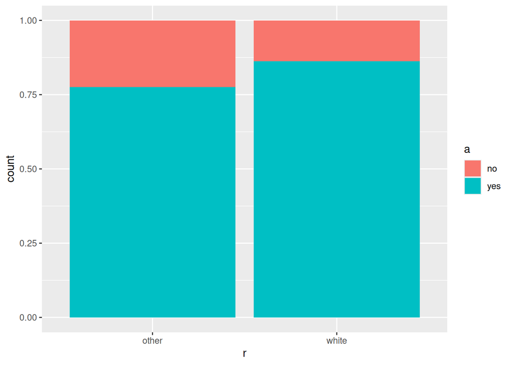

```r
ggplot(use, aes(x = r, y = count, fill = a)) + geom_col(position = "fill")
```

The right-hand blue piece is slightly bigger, so if a student is white, they are more likely to have used alcohol than if they were a student of some other race. (This difference, though small, is significant, which is why we are looking at it.)

`a:g` is done the same way as `a:r`:

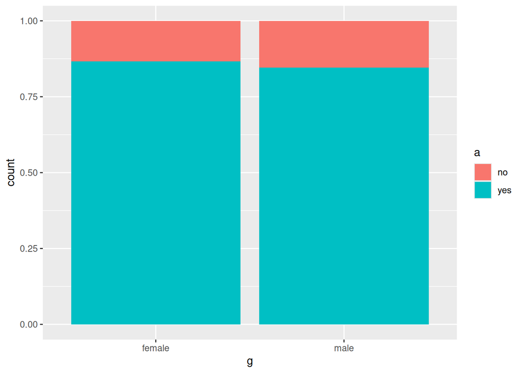

```r
ggplot(use, aes(x = g, y = count, fill = a)) + geom_col(position = "fill")
```

If a student is female, they are very slightly more likely to have used alcohol than if they are male. This tiny difference is in fact significant, though the P-value is 0.019, which is not *very* small. Because there is so much data, significant effects can be small, and this appears to be one of those.

`m:g` is done the same way again:

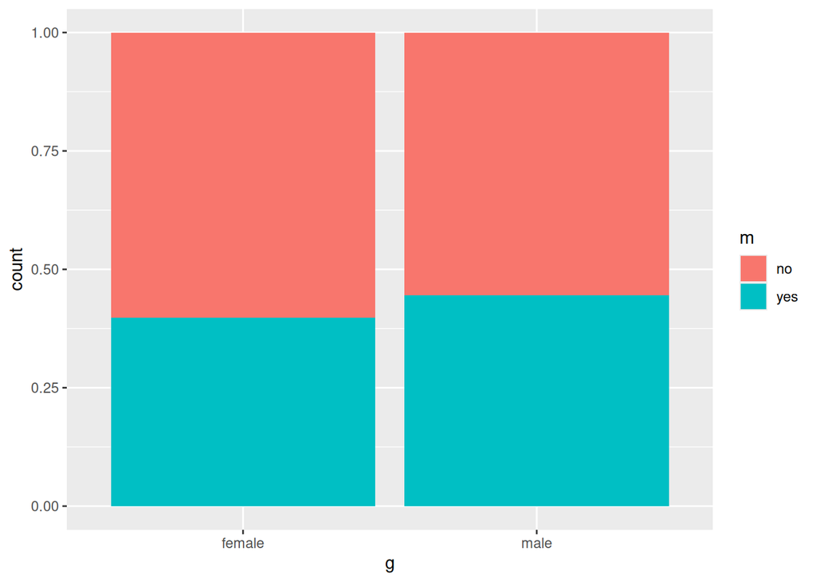

```r
ggplot(use, aes(x = g, y = count, fill = m)) + geom_col(position = "fill")
```

If a student is male, they are (a little) more likely to use marijuana than if the student is female. Again, a small but significant difference.

When you have two variables of the same type (in this problem, both responses), it doesn’t matter which one is `x` and which one is `fill`, as long as your explanation matches up: for each category of the thing in `x`, what happens to the thing in `fill`?

`a:c`:

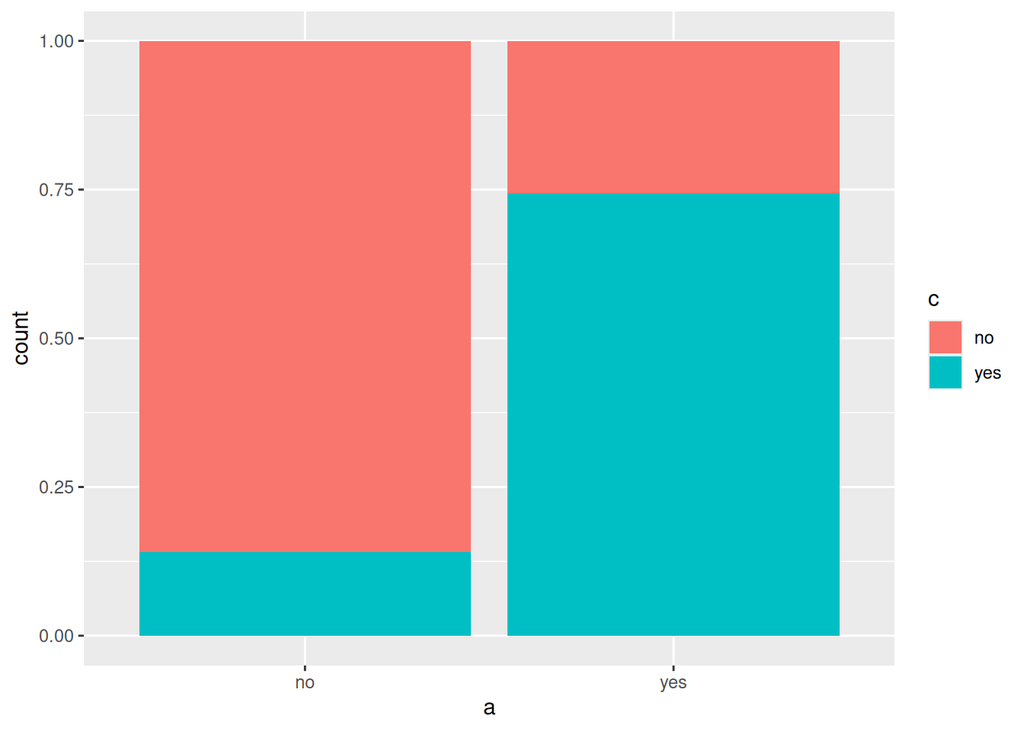

```r
ggplot(use, aes(x = a, y = count, fill = c)) + geom_col(position = "fill")
```

Students that have used alcohol are more likely to have used cigarettes as well (and the ones that haven’t used alcohol probably haven’t used cigarettes either). That is to say, alcohol and cigarette use go together. This is interesting, but it is a sort of secondary conclusion; you might imagine that the survey people were really interested in a question like “what kinds of young people tend to use alcohol or cigarettes or marijuana?” and this graph doesn’t help in answering *that* question.

Or, if you prefer:

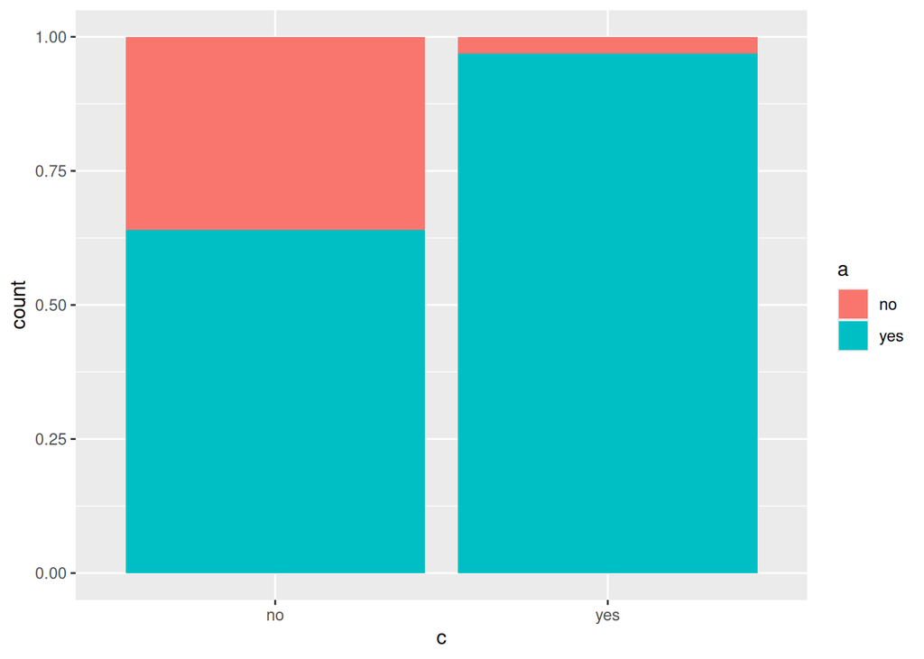

```r
ggplot(use, aes(x = c, y = count, fill = a)) + geom_col(position = "fill")
```

and the relevant conclusion is that if a student has used cigarettes, they have almost certainly used alcohol as well (and if they haven’t used cigarettes, they are much less likely to have used alcohol, even though the chance is not small).

The implication here is that these patterns are consistent over race. If they were not, we would have an `a:c:r` interaction, implying that race affects the combination of alcohol and cigarette use. But see the next question.

`a:m` are also both responses:

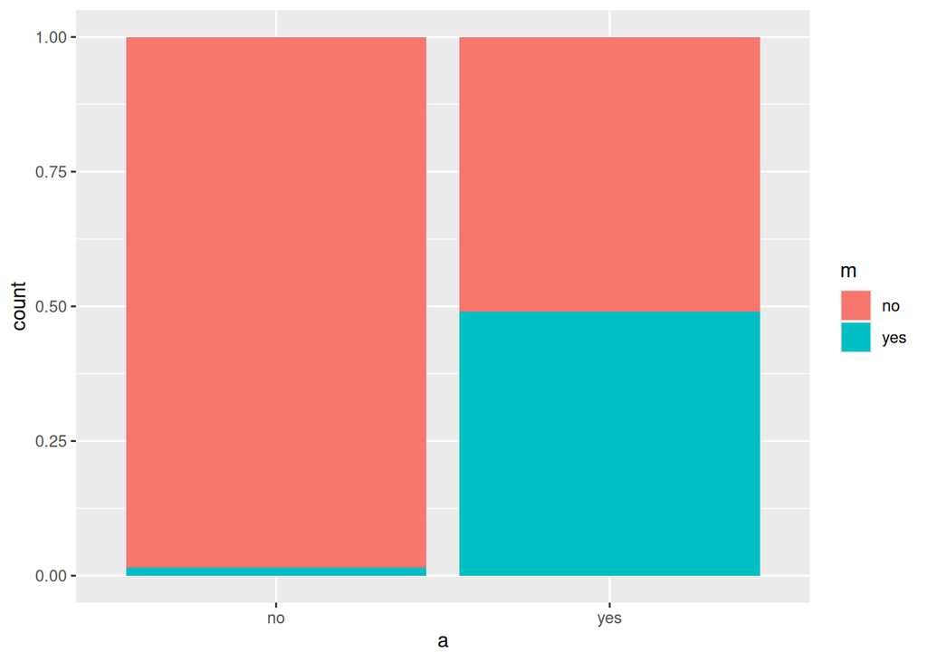

```r
ggplot(use, aes(x = a, y = count, fill = m)) + geom_col(position = "fill")
```

Almost all the students who have not used alcohol have not used marijuana either, but of the students that *have* used alcohol, about half of them have used marijuana as well. Once again, students who have used one are more likely to have used the other as well.

Once again, the implication is that this pattern holds over all genders and races, otherwise we would have had a higher-order interaction in the model.[^2]

Finally, `c:m`:

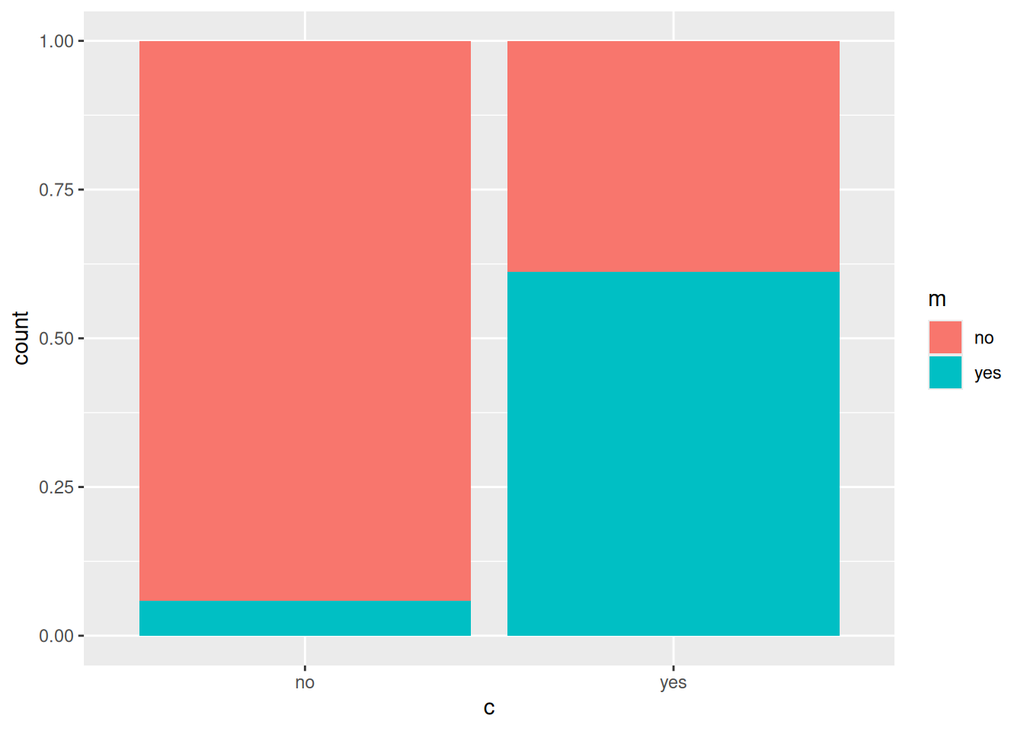

```r
ggplot(use, aes(x = c, y = count, fill = m)) + geom_col(position = "fill")
```

I wouldn’t give you a question this long on an exam, but on a worksheet, there is no problem with giving you plenty of practice.

5. We can also use `step` to do the model-building (rather than removing terms one by one). Starting from all *three*-way interactions, run `step` on this model, saving the result, and then run `drop1` on that result. Is everything remaining significant? (Hint: copy and paste your code from question 2, and change the 2 to a 3.)

Following the hint(s). The output is rather long, but (i) you are not handing this in, and (ii) we have no problems with letting R do the work:

```r
use.6 <- glm(count ~ (a+c+m+r+g)^3, data = use, family = "poisson")
use.7 <- step(use.6)
```

```
Start:  AIC=193.51
count ~ (a + c + m + r + g)^3

        Df Deviance    AIC
- c:m:r  1   5.2820 191.52
- m:r:g  1   5.3000 191.54
- a:m:g  1   5.3924 191.63
- a:m:r  1   5.4349 191.67
- a:c:g  1   5.5868 191.82
- a:c:m  1   5.6749 191.91
- c:r:g  1   6.4173 192.66
- c:m:g  1   6.7775 193.02
<none>       5.2720 193.51
- a:r:g  1   7.8942 194.13
- a:c:r  1   7.9474 194.19

Step:  AIC=191.52
count ~ a + c + m + r + g + a:c + a:m + a:r + a:g + c:m + c:r +
    c:g + m:r + m:g + r:g + a:c:m + a:c:r + a:c:g + a:m:r + a:m:g +
    a:r:g + c:m:g + c:r:g + m:r:g

        Df Deviance    AIC
- m:r:g  1   5.3091 189.55
- a:m:g  1   5.4028 189.64
- a:m:r  1   5.4545 189.69
- a:c:g  1   5.5977 189.84
- a:c:m  1   5.6939 189.93
- c:r:g  1   6.4173 190.66
- c:m:g  1   6.7824 191.02
<none>       5.2820 191.52
- a:r:g  1   7.8976 192.14
- a:c:r  1   8.0316 192.27

Step:  AIC=189.55
count ~ a + c + m + r + g + a:c + a:m + a:r + a:g + c:m + c:r +
    c:g + m:r + m:g + r:g + a:c:m + a:c:r + a:c:g + a:m:r + a:m:g +
    a:r:g + c:m:g + c:r:g

        Df Deviance    AIC
- a:m:g  1   5.4343 187.67
```

[output cut: 115 more lines]

```
- a:m    1   102.60 268.84
- c:m    1   508.34 674.58

Step:  AIC=179.29
count ~ a + c + m + r + g + a:c + a:m + a:r + a:g + c:m + c:r +
    m:r + m:g + a:c:r

        Df Deviance    AIC
<none>        13.05 179.29
- m:r    1    15.15 179.39
- a:c:r  1    17.13 181.37
- a:g    1    18.56 182.80
- m:g    1    21.95 186.19
- a:m    1   103.43 267.67
- c:m    1   509.16 673.39
```

```r
drop1(use.7, test = "Chisq")
```

|  | Df | Deviance | AIC | LRT | Pr(>Chi) |
| --- | --- | --- | --- | --- | --- |
|  | NA | 13.05485 | 179.2931 | NA | NA |
| a:m | 1 | 103.42732 | 267.6656 | 90.372474 | 1.972919e-21 |
| a:g | 1 | 18.56451 | 182.8028 | 5.509665 | 1.891167e-02 |
| c:m | 1 | 509.15547 | 673.3937 | 496.100623 | 6.705061e-110 |
| m:r | 1 | 15.15401 | 179.3923 | 2.099164 | 1.473797e-01 |
| m:g | 1 | 21.95134 | 186.1896 | 8.896493 | 2.857190e-03 |
| a:c:r | 1 | 17.13084 | 181.3691 | 4.075991 | 4.349673e-02 |

As you see, the process is rather lengthy, which is why I didn’t have you do it by hand.

There is one term in `use.7`, `m:r`, that is not significant (P-value 0.15). You could remove it if you wish.

6. In your final model from the previous question, are there any significant terms that you did not see previously? If so, in each case draw a suitable graph and say what it means.

There is one remaining three-way interaction `a:c:r`. One way of interpreting this is that race is associated with the alcohol-cigarettes *combination*.

With three variables, we have to use `x`, `fill` *and* facets. I think the one explanatory variable `r` belongs in facets (but you can experiment and see which you prefer):

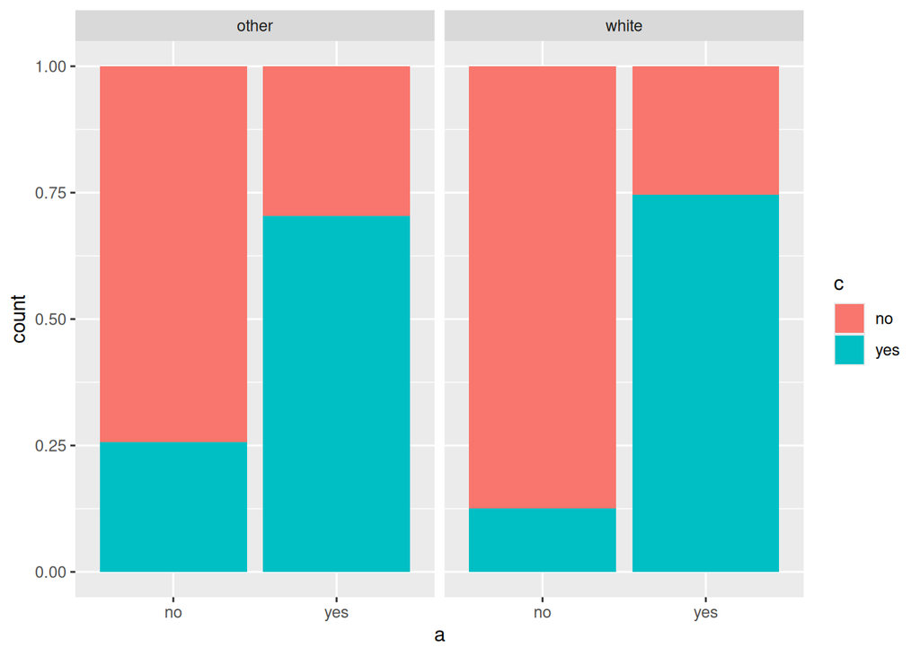

```r
ggplot(use, aes(x = a, y = count, fill = c)) + geom_col(position = "fill") +
  facet_wrap(~ r)
```

The pattern in the two facets is more or less the same: if a student has used alcohol, they are more likely to have used cigarettes as well. Perhaps the reason for the interaction term being significant is that the no-no pattern is a bit more pronounced for the white students than it is for students of other races: if a white student has not used alcohol (left bar in the right facet), they are more likely to have not used cigarettes either, compared to a student of another race. (The three-way association is only just significant, with a P-value of 0.043, so we would not expect the effect to be very large, and indeed it is not.)

## Footnotes

[^1]: This is the only kind of “stacked bars” I like.
[^2]: Except that we didn’t fit any higher-order interactions in the first place, but see the next question.